# STAT 415 Project

Bryan Veres, Casey Ng

3/10/2021

# 1. Research question and context

Basketball is a relatively simple game, you shoot a ball into a hoop and you get points. If you end up with more points than the other team, you win. At the highest level of play, a basketball game is 48 minutes long. In a game, there’ll be about 15 players that you can switch around throughout the game. Obviously you’ll want your better players on the court longer to increase your chances of winning but not in the whole game which will exhaust them. Another important aspect in scoring points is shooting percentage. For example, scoring 20 points on 10 shots is more impactful than scoring 20 points on 20 shots. We wanted to research if we can use minutes per game played and true shooting percentage to predict the number of points made per 36 minutes.

# 2. Data set

https://github.com/fivethirtyeight/nba-player-advanced-metrics?fbclid=IwAR0N-fvRFmpBKqHvWP7_bTdgPYtxp0jWeX1ssV4SXfoAK8MJ1n9kIWNzd1I

# 3. Discuss data and how it was collected

The data was taken from 538, a website that uses statistical analysis to tell stories about politics, science, sports, etc. NBA data is usually collected using cameras that record the movement of the ball and every player on the court. NBA advanced stats can also usually be found on their website or other websites that archive basketball stats like basketball reference. For the variables we are using, minutes per game is pretty simple, the average number of minutes a player is on the court per game for a season. True shooting percentage is taken from the number of points made and divided by 2 times by true shooting attempts (field goal attempts +0.44*free throw attempts). We are using this statistic since it’s the most accurate measure of shooting efficiency that takes field goals, three point field goals and free throws into account. Points per 36 minutes takes point average, divided by minutes played per game and then multiplied by 36. Because this data set is extremely large we decided to filter the data to just 2019, the last complete 82 game regular season.

```r
data <- read_csv("C:/Users/Casey/Desktop/STAT415/nba-data-historical.csv")
```

```r
data <- data %>%
  filter(year_id == 2019 & !is.na(`TS%`))
```

# 4.Propose a Bayesian model

Given that we wanted to see if minutes per game and true shooting percentage are good predictors of points per 36 minutes, which are all quantitative variables, we propose that a Bayesian analysis of multiple regression would best model this relationship.

# 5. Discuss choice of prior and likelihood

As a note, we first tried the model without centering the true shooting percentage. However, this model did not work well with the Gibbs sampling as the diagnostic plots were not good for values of $\beta_0$ and $\beta_1$, as the autocorrelations decayed very slowly. Once the true shooting percentage was centered, the autocorrelations for both Beta0 and Beta1 decayed fairly fast, along with $\beta_2$.

# 6. Fitting the Model

```r
modelString <- "model {

  ## sampling
  for (i in 1:N) {
    y[i] ~ dnorm(beta0 + beta1*x_min[i] + beta2*(x_ts[i]-mean(x_ts)), sigma2)
  }

  ## Priors
  beta0 ~ dnorm(mu0, g0)
  beta1 ~ dnorm(mu1, g1)
  beta2 ~ dnorm(mu2, g2)
  sigma2 ~ dgamma(a, b)
  sigma <- sqrt(pow(sigma2, -1))

}"
```

```r
y <- as.vector(data$`P/36`)
x_min <- as.vector(data$MPG)
x_ts <- as.vector(data$`TS%`)
N <- length(y)
the_data <- list("y" = y,
                 "x_min" = x_min, "x_ts" = x_ts,
                 "N" = N,
                 "mu0" = 0, "g0" = 0.0025,
                 "mu1" = 0, "g1" = 0.0025,
                 "mu2" = 0, "g2" = 0.0025,
                 "a" = 0.001, "b" = 0.001)
```

```r
model <- jags.model(textConnection(modelString),
                    data = the_data,
                    n.chains = 5)
update(model, 1000, progress.bar = "none");

posterior_sample <- coda.samples(model,
                                 variable.names = c("beta0", "beta1", "beta2", "sigma2"),
                                 n.iter = 10000, progress.bar="none")
summary(posterior_sample)
```

```
##
## Iterations = 1001:11000
## Thinning interval = 1
## Number of chains = 5
## Sample size per chain = 10000
##
## 1. Empirical mean and standard deviation for each variable,
##    plus standard error of the mean:
##
##            Mean       SD  Naive SE Time-series SE
## beta0  11.79461 0.452342 2.023e-03      6.708e-03
## beta1   0.15601 0.021189 9.476e-05      3.138e-04
## beta2   0.23806 0.016227 7.257e-05      9.401e-05
## sigma2  0.04706 0.002687 1.202e-05      1.211e-05
##
## 2. Quantiles for each variable:
##
##            2.5%      25%      50%      75%    97.5%
## beta0  10.90064 11.49042 11.79569 12.09866 12.68292
## beta1   0.11444  0.14156  0.15594  0.17020  0.19791
## beta2   0.20654  0.22714  0.23812  0.24903  0.26976
## sigma2  0.04196  0.04522  0.04701  0.04883  0.05244
```

# 7. Posterior inference

[figure not shown]

```r
plot(posterior_sample)
```

```r
params <- as.matrix(posterior_sample)
beta0 <- params[,1]
beta1 <- params[,2]
beta2 <- params[,3]
sigma2 <- params[,4]
```

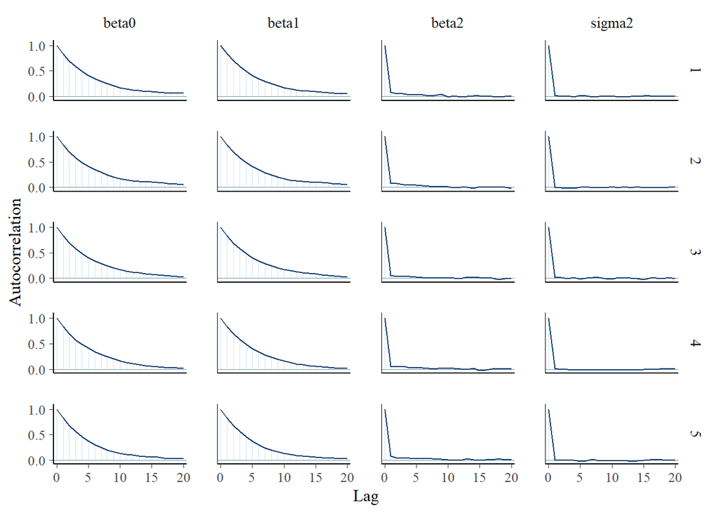

```r
mcmc_acf(posterior_sample)
```

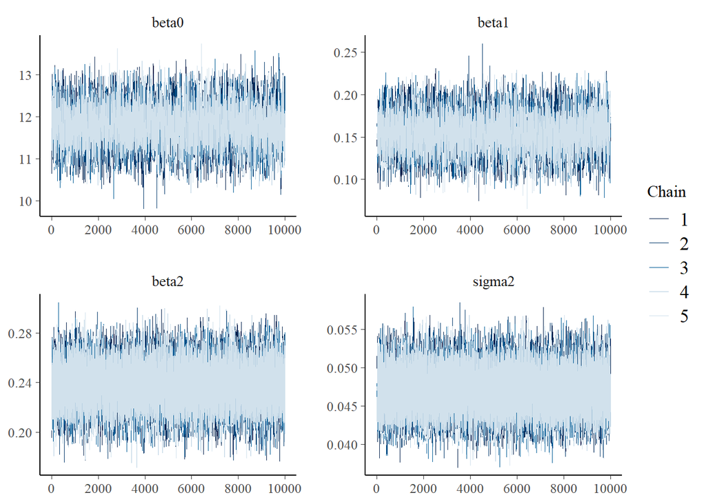

```r
mcmc_trace(posterior_sample)
```

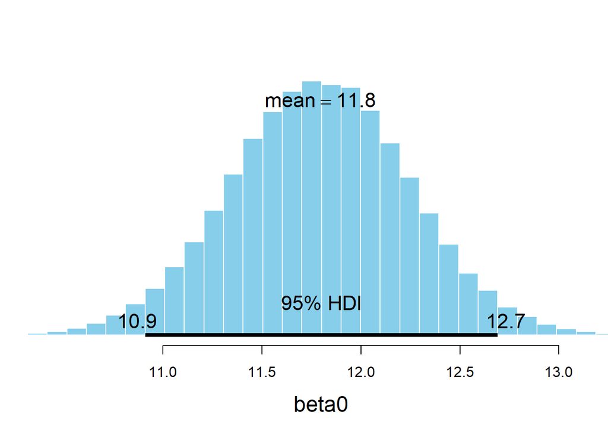

```r
plotPost(beta0)
```

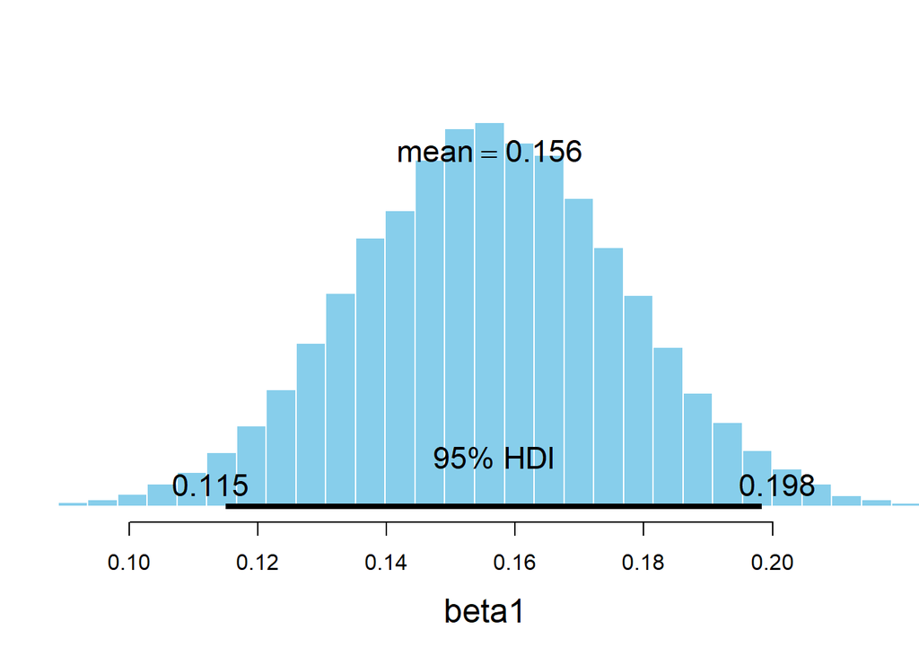

```r
plotPost(beta1)
```

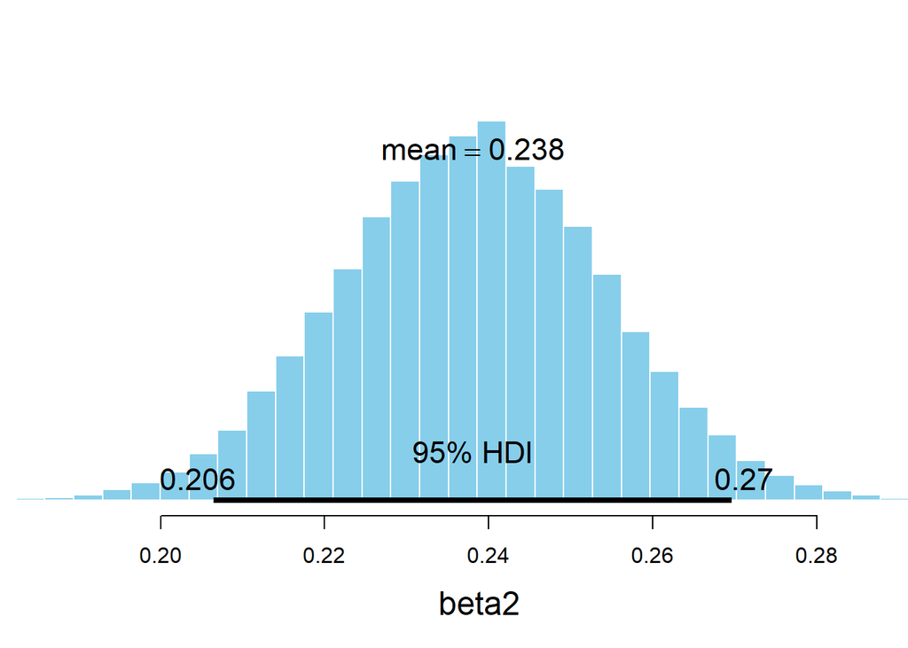

```r
plotPost(beta2)
```

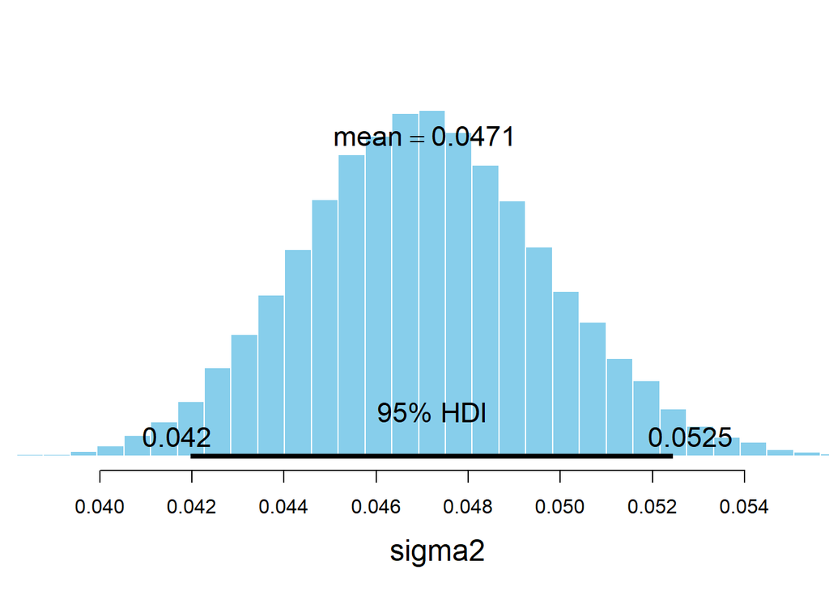

```r
plotPost(sigma2)
```

# 8. Posterior prediction

For posterior prediction, we found posterior predictive distributions for current players using their current MPG’s and TS% from this year, namely Stephen Curry and Draymond Green.

Using Steph Curry’s current MPG and TS%, we found that there is a posterior predictive probability of 95% that the P/36 of a player who plays 34.1 minutes per game and has a true shooting percentage of 64.6 is between 19.11 and 20.57. Roughly, 95% of players with 34.1 MPG and a 64.6 TS% score between 19.11 and 20.57 P/36.

Using Draymond Green’s’ current MPG and TS%, we found that there is a posterior predictive probability of 95% that the P/36 of a player who plays 29.6 minutes per game and has a true shooting percentage of 46.4 is between 14.16 and 15.45. Roughly, 95% of players with 29.6 MPG and a 46.4 TS% score between 14.16 and 15.45 P/36.

## Stephen Curry

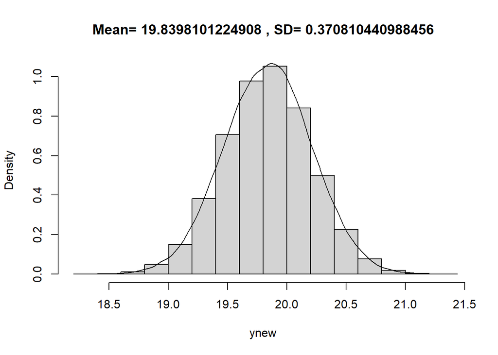

```r
min_new = 34.1
ts_new = 64.6
ynew = beta0 + beta1*min_new + beta2*(ts_new - mean(x_ts)) + sigma2*rnorm(50000, 0, 1)
hist(ynew, freq = FALSE, main=paste("Mean=", mean(ynew), ", SD=", sd(ynew)))
lines(density(ynew))
```

```r
quantile(ynew, c(0.025, 0.975))
```

```
##     2.5%    97.5%
## 19.11146 20.56558
```

## Draymond Green

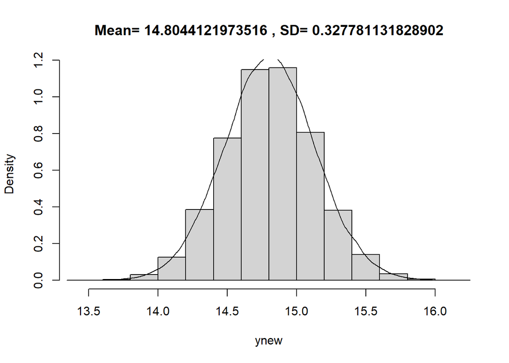

```r
min_new = 29.6
ts_new = 46.4
ynew = beta0 + beta1*min_new + beta2*(ts_new - mean(x_ts)) + sigma2*rnorm(50000, 0, 1)
hist(ynew, freq = FALSE, main=paste("Mean=", mean(ynew), ", SD=", sd(ynew)))
lines(density(ynew))
```

```r
quantile(ynew, c(0.025, 0.975))
```

```
##     2.5%    97.5%
## 14.16161 15.45165
```

# 9. Posterior predictive checking or model comparison

Firstly, we perform posterior predictive checking by computing posterior predictive intervals for P/36 for a variety of values of minutes per game, adjusting for the true shooting percentage, using the sample mean TS%, sample 25th percentile and sample 75th percentile as the values of x_ts. Based on the scatterplots we see that most observed values of P/36 fall near/along the centers of the predictive intervals. However, since the predictive intervals have very small standard deviations, likely due to the large observed sample size, most values don’t fall within the intervals.

Next, performing posterior predictive checking similarly for the true shooting percentage by computing posterior predictive intervals for P/36 for a variety of values of true shooting percentage, adjusting for minutes per game, by using the sample mean MPG, sample 25th percentile and sample 75th percentile as the values of x_min. Based on the scatterplots, similarly to the plots for minutes per game, we see that most observed values of P/36 fall around the predictive intervals, but not within the intervals due to the intervals having such small standard deviations.

Although, the predicted intervals seem to follow the overall trend of the data, we model might require adjustment given that most of the sample data falls outside of the intervals.

## Minutes Per Game

### TS% = Sample Mean TS%

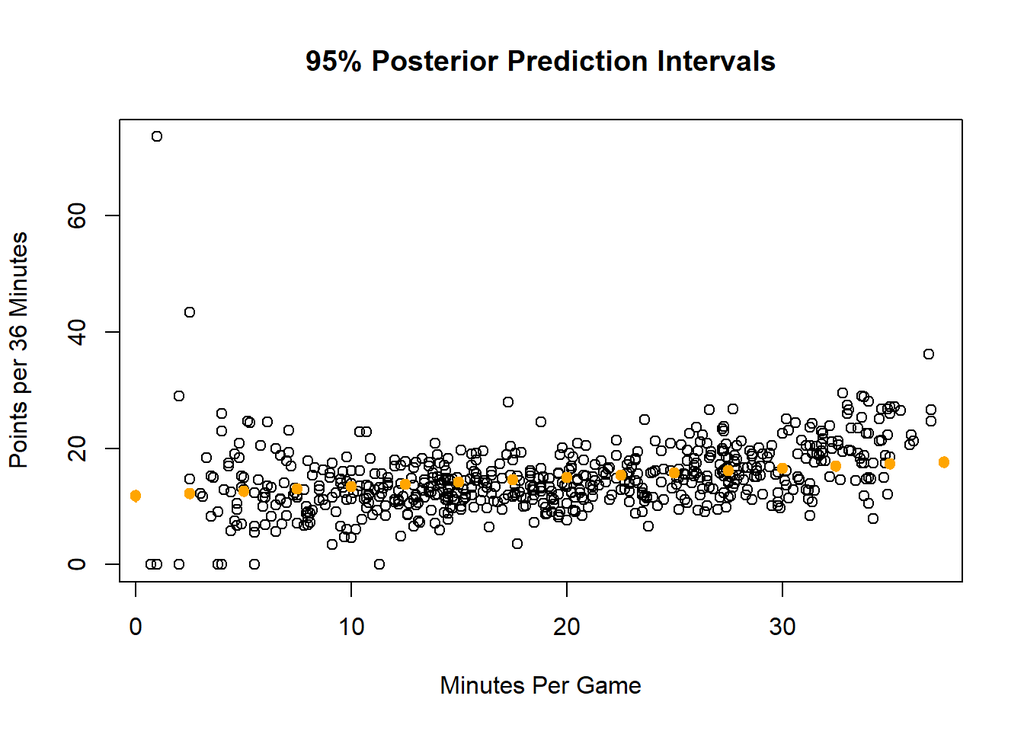

```r
plot(data$MPG, data$`P/36`, xlab = "Minutes Per Game", ylab = "Points per 36 Minutes",
     main = "95% Posterior Prediction Intervals")

xnew = seq(0, 37.5, 2.5)

for (xx in xnew) {
  ynew = beta0 + beta1 * (xx) + sigma2 * rnorm(50000, 0, 1)
  segments(x0 = xx, y0 = quantile(ynew, 0.025), x1 = xx,
           y1 = quantile(ynew, 0.975), col = "orange", lwd=2)
  points(x = xx, y = mean(ynew), pch = 19, col = "orange")
}
```

### TS% = Sample 25th Percentile TS%

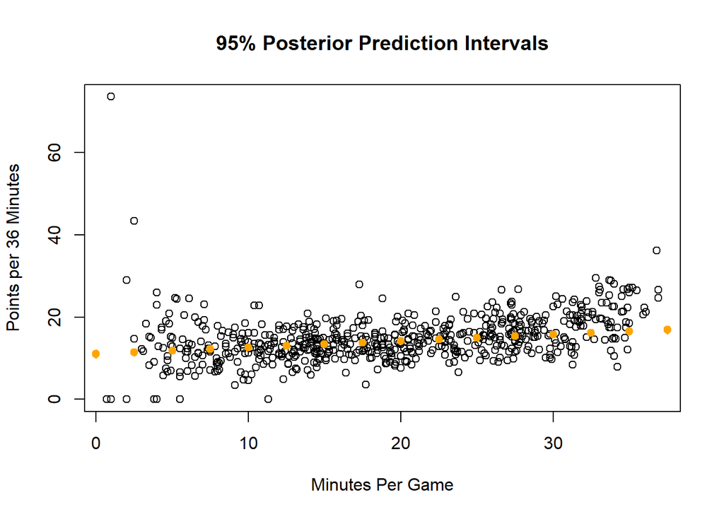

```r
plot(data$MPG, data$`P/36`, xlab = "Minutes Per Game", ylab = "Points per 36 Minutes",
     main = "95% Posterior Prediction Intervals")

xnew = seq(0, 37.5, 2.5)

for (xx in xnew) {
  ynew = beta0 + beta1 * (xx) + beta2 * (quantile(x_ts, 0.25) - mean(x_ts)) + sigma2 * rnorm(50000, 0, 1)
  segments(x0 = xx, y0 = quantile(ynew, 0.025), x1 = xx,
           y1 = quantile(ynew, 0.975), col = "orange", lwd=2)
  points(x = xx, y = mean(ynew), pch = 19, col = "orange")
}
```

### TS% = Sample 75th Percentile TS%

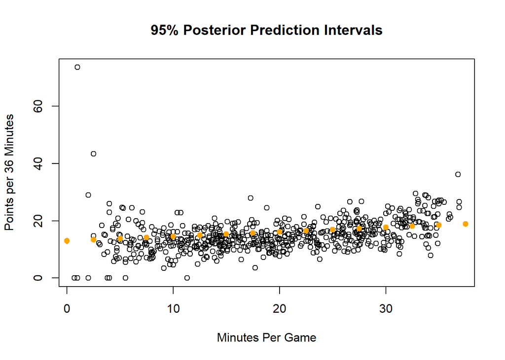

```r
plot(data$MPG, data$`P/36`, xlab = "Minutes Per Game", ylab = "Points per 36 Minutes",
     main = "95% Posterior Prediction Intervals")

xnew = seq(0, 37.5, 2.5)

for (xx in xnew) {
  ynew = beta0 + beta1 * (xx) + beta2 * (quantile(x_ts, 0.75) - mean(x_ts)) + sigma2 * rnorm(50000, 0, 1)
  segments(x0 = xx, y0 = quantile(ynew, 0.025), x1 = xx,
           y1 = quantile(ynew, 0.975), col = "orange", lwd=2)
  points(x = xx, y = mean(ynew), pch = 19, col = "orange")
}
```

## True Shooting Percentage

### Minutes Per Game = Sample Mean MPG

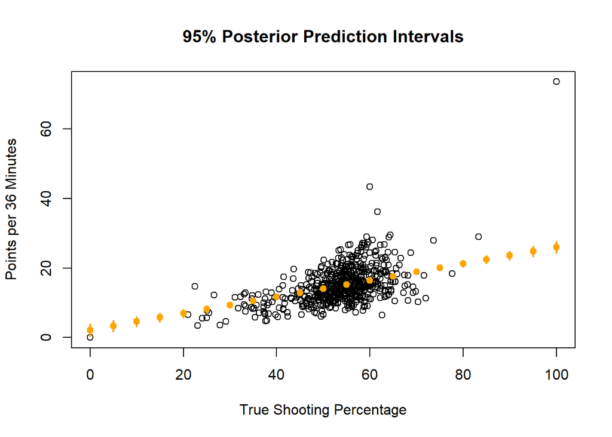

```r
plot(data$`TS%`, data$`P/36`, xlab = "True Shooting Percentage", ylab = "Points per 36 Minutes",
     main = "95% Posterior Prediction Intervals", xlim = c(0, 100))

xnew = seq(0, 100, 5)

for (xx in xnew) {
  ynew = beta0 + beta1*mean(x_min) + beta2 * (xx - mean(x_ts)) + sigma2 * rnorm(50000, 0, 1)
  segments(x0 = xx, y0 = quantile(ynew, 0.025), x1 = xx,
           y1 = quantile(ynew, 0.975), col = "orange", lwd=2)
  points(x = xx, y = mean(ynew), pch = 19, col = "orange")
}
```